# Project: Medical Appointment Data Analysis

- Introduction
- Data Wrangling
- Exploratory Data Analysis
- Conclusions

## Introduction

This dataset contains information on over a hundred thousand medical appointments in Brazil, and focuses mainly on the question whether or not patients show up for their appointments. For each row, there is information on a number of characteristics of the patient such as the patient's id, gender, age, appointment date, and so on.

### Questions for Analysis

- How often did people miss appointments?
- Does the gender of the patient has a relation with the absence?
- Does the age of the patient have a relation with the absence?
- Did patients miss appointments because of not receiving a message??
- Does the scholarship affect the patient's attendance?

```python
# Importing all needed libraries that would be used.
import pandas as pd
import numpy as np
import seaborn as sns
import matplotlib.pyplot as plt
%matplotlib inline
```

## Data Wrangling

In this section the report, the data would be loaded, checked for cleanliness, and then trimed and cleaned for analysis.

### General Properties

```python
# Loading the data and displaying first 5 few lines.
df= pd.read_csv('noshowappointments-kagglev2-may-2016.csv')
df.head()
```

|  | PatientId | AppointmentID | Gender | ScheduledDay | AppointmentDay | Age | Neighbourhood | Scholarship | Hipertension | Diabetes | Alcoholism | Handcap | SMS_received | No-show |
| --- | --- | --- | --- | --- | --- | --- | --- | --- | --- | --- | --- | --- | --- | --- |
| 0 | 2.987250e+13 | 5642903 | F | 2016-04-29T18:38:08Z | 2016-04-29T00:00:00Z | 62 | JARDIM DA PENHA | 0 | 1 | 0 | 0 | 0 | 0 | No |
| 1 | 5.589978e+14 | 5642503 | M | 2016-04-29T16:08:27Z | 2016-04-29T00:00:00Z | 56 | JARDIM DA PENHA | 0 | 0 | 0 | 0 | 0 | 0 | No |
| 2 | 4.262962e+12 | 5642549 | F | 2016-04-29T16:19:04Z | 2016-04-29T00:00:00Z | 62 | MATA DA PRAIA | 0 | 0 | 0 | 0 | 0 | 0 | No |
| 3 | 8.679512e+11 | 5642828 | F | 2016-04-29T17:29:31Z | 2016-04-29T00:00:00Z | 8 | PONTAL DE CAMBURI | 0 | 0 | 0 | 0 | 0 | 0 | No |
| 4 | 8.841186e+12 | 5642494 | F | 2016-04-29T16:07:23Z | 2016-04-29T00:00:00Z | 56 | JARDIM DA PENHA | 0 | 1 | 1 | 0 | 0 | 0 | No |

```python
#Checking the shape of the data. number of colomns and rows.
df.shape
```

```
(110527, 14)
```

```python
#Displaying other basic information about the data such as datatypes for each column
#and possible missing data
df.info()
```

```
<class 'pandas.core.frame.DataFrame'>
RangeIndex: 110527 entries, 0 to 110526
Data columns (total 14 columns):
 #   Column          Non-Null Count   Dtype
---  ------          --------------   -----
 0   PatientId       110527 non-null  float64
 1   AppointmentID   110527 non-null  int64
 2   Gender          110527 non-null  object
 3   ScheduledDay    110527 non-null  object
 4   AppointmentDay  110527 non-null  object
 5   Age             110527 non-null  int64
 6   Neighbourhood   110527 non-null  object
 7   Scholarship     110527 non-null  int64
 8   Hipertension    110527 non-null  int64
 9   Diabetes        110527 non-null  int64
 10  Alcoholism      110527 non-null  int64
 11  Handcap         110527 non-null  int64
 12  SMS_received    110527 non-null  int64
 13  No-show         110527 non-null  object
dtypes: float64(1), int64(8), object(5)
memory usage: 11.8+ MB
```

The ouput shows that there are 110,527 entries described by 14 fields. There are also no null fields

```python
#checking if there are any duplicated information
df.duplicated()
```

```
0         False
1         False
2         False
3         False
4         False
          ...
110522    False
110523    False
110524    False
110525    False
110526    False
Length: 110527, dtype: bool
```

```python
#checking the sum of the duplicated data
df.duplicated().sum()
```

```
0
```

```python
#checking for how many unique entries in each column
df.nunique()
```

```
PatientId          62299
AppointmentID     110527
Gender                 2
ScheduledDay      103549
AppointmentDay        27
Age                  104
Neighbourhood         81
Scholarship            2
Hipertension           2
Diabetes               2
Alcoholism             2
Handcap                5
SMS_received           2
No-show                2
dtype: int64
```

This results shows that, there are as many unique AppointmentIDs as there are rows but it seems not to be so for the other columns. Because the AppointmentIDs are unique to each row it will be set as the dataframe index.

```python
# seting AppointmentID as the dataframe index.
df.set_index('AppointmentID', inplace=True ,verify_integrity=True)
df.head()
```

| AppointmentID | PatientId | Gender | ScheduledDay | AppointmentDay | Age | Neighbourhood | Scholarship | Hipertension | Diabetes | Alcoholism | Handcap | SMS_received | No-show |
| --- | --- | --- | --- | --- | --- | --- | --- | --- | --- | --- | --- | --- | --- |
| 5642903 | 2.987250e+13 | F | 2016-04-29T18:38:08Z | 2016-04-29T00:00:00Z | 62 | JARDIM DA PENHA | 0 | 1 | 0 | 0 | 0 | 0 | No |
| 5642503 | 5.589978e+14 | M | 2016-04-29T16:08:27Z | 2016-04-29T00:00:00Z | 56 | JARDIM DA PENHA | 0 | 0 | 0 | 0 | 0 | 0 | No |
| 5642549 | 4.262962e+12 | F | 2016-04-29T16:19:04Z | 2016-04-29T00:00:00Z | 62 | MATA DA PRAIA | 0 | 0 | 0 | 0 | 0 | 0 | No |
| 5642828 | 8.679512e+11 | F | 2016-04-29T17:29:31Z | 2016-04-29T00:00:00Z | 8 | PONTAL DE CAMBURI | 0 | 0 | 0 | 0 | 0 | 0 | No |
| 5642494 | 8.841186e+12 | F | 2016-04-29T16:07:23Z | 2016-04-29T00:00:00Z | 56 | JARDIM DA PENHA | 0 | 1 | 1 | 0 | 0 | 0 | No |

Among the numeric fields in the data, Scholarship, Hipertension, Diabetes, Alcoholism, Handicap and SMS_received seem to be binary fields. This can be verified using the describe method from Pandas.

```python
#Checking basic statistical description of the data
df.describe()
```

|  | PatientId | Age | Scholarship | Hipertension | Diabetes | Alcoholism | Handcap | SMS_received |
| --- | --- | --- | --- | --- | --- | --- | --- | --- |
| count | 1.105270e+05 | 110527.000000 | 110527.000000 | 110527.000000 | 110527.000000 | 110527.000000 | 110527.000000 | 110527.000000 |
| mean | 1.474963e+14 | 37.088874 | 0.098266 | 0.197246 | 0.071865 | 0.030400 | 0.022248 | 0.321026 |
| std | 2.560949e+14 | 23.110205 | 0.297675 | 0.397921 | 0.258265 | 0.171686 | 0.161543 | 0.466873 |
| min | 3.921784e+04 | -1.000000 | 0.000000 | 0.000000 | 0.000000 | 0.000000 | 0.000000 | 0.000000 |
| 25% | 4.172614e+12 | 18.000000 | 0.000000 | 0.000000 | 0.000000 | 0.000000 | 0.000000 | 0.000000 |
| 50% | 3.173184e+13 | 37.000000 | 0.000000 | 0.000000 | 0.000000 | 0.000000 | 0.000000 | 0.000000 |
| 75% | 9.439172e+13 | 55.000000 | 0.000000 | 0.000000 | 0.000000 | 0.000000 | 0.000000 | 1.000000 |
| max | 9.999816e+14 | 115.000000 | 1.000000 | 1.000000 | 1.000000 | 1.000000 | 4.000000 | 1.000000 |

All of fields except for Handcap range between 0 and 1, which has a maximum value of 4. It seems that Handcap represents the total number of handicaps the patient has.

### Data Cleaning

From the statistical description above, one would noticed that the minimum age is -1 which is strange value and possibly a mistake. For this reason,that age value would be dropped.

```python
#Checking for rows with with with age value less than zero
Neg_age = df[df['Age'] < 0 ]
Neg_age
```

| AppointmentID | PatientId | Gender | ScheduledDay | AppointmentDay | Age | Neighbourhood | Scholarship | Hipertension | Diabetes | Alcoholism | Handcap | SMS_received | No-show |
| --- | --- | --- | --- | --- | --- | --- | --- | --- | --- | --- | --- | --- | --- |
| 5775010 | 4.659432e+14 | F | 2016-06-06T08:58:13Z | 2016-06-06T00:00:00Z | -1 | ROMÃO | 0 | 0 | 0 | 0 | 0 | 0 | No |

```python
#Dropping row with with age value as -1
df.drop(df.index[df['Age'] == -1], inplace =True)
```

```python
#Checking if age was effected
df[df['Age'] < 0  ]
```

|  | PatientId | Gender | ScheduledDay | AppointmentDay | Age | Neighbourhood | Scholarship | Hipertension | Diabetes | Alcoholism | Handcap | SMS_received | No-show |
| --- | --- | --- | --- | --- | --- | --- | --- | --- | --- | --- | --- | --- | --- |
| AppointmentID |  |  |  |  |  |  |  |  |  |  |  |  |  |

```python
#Confirming change of the minimum age value
df.describe()
```

|  | PatientId | Age | Scholarship | Hipertension | Diabetes | Alcoholism | Handcap | SMS_received |
| --- | --- | --- | --- | --- | --- | --- | --- | --- |
| count | 1.105260e+05 | 110526.000000 | 110526.000000 | 110526.000000 | 110526.000000 | 110526.000000 | 110526.000000 | 110526.000000 |
| mean | 1.474934e+14 | 37.089219 | 0.098266 | 0.197248 | 0.071865 | 0.030400 | 0.022248 | 0.321029 |
| std | 2.560943e+14 | 23.110026 | 0.297676 | 0.397923 | 0.258266 | 0.171686 | 0.161543 | 0.466874 |
| min | 3.921784e+04 | 0.000000 | 0.000000 | 0.000000 | 0.000000 | 0.000000 | 0.000000 | 0.000000 |
| 25% | 4.172536e+12 | 18.000000 | 0.000000 | 0.000000 | 0.000000 | 0.000000 | 0.000000 | 0.000000 |
| 50% | 3.173184e+13 | 37.000000 | 0.000000 | 0.000000 | 0.000000 | 0.000000 | 0.000000 | 0.000000 |
| 75% | 9.438963e+13 | 55.000000 | 0.000000 | 0.000000 | 0.000000 | 0.000000 | 0.000000 | 1.000000 |
| max | 9.999816e+14 | 115.000000 | 1.000000 | 1.000000 | 1.000000 | 1.000000 | 4.000000 | 1.000000 |

From the data info loaded above, one would notice that the datatype for AppointmentDay and ScheduledDay were both object which isn't right considering contain information on dates. That needs to be changed.

```python
#Changing AppointmentDay to datetime data type
df['AppointmentDay']= pd.to_datetime(df['AppointmentDay'])
```

```python
#Changing ScheduledDay to datetime data type
df['ScheduledDay'] = pd.to_datetime(df['ScheduledDay'])
```

```python
#Checking if change was effected
df.dtypes
```

```
PatientId                     float64
Gender                         object
ScheduledDay      datetime64[ns, UTC]
AppointmentDay    datetime64[ns, UTC]
Age                             int64
Neighbourhood                  object
Scholarship                     int64
Hipertension                    int64
Diabetes                        int64
Alcoholism                      int64
Handcap                         int64
SMS_received                    int64
No-show                        object
dtype: object
```

The day of week value can now be extracted from the AppointmentDay field to answer one of the research questions.

```python
#extracting day of the week from the AppointmentDay and creating a new column to display them
df['DayOfWeek'] = df['AppointmentDay'].dt.day_name()
df.head()
```

| AppointmentID | PatientId | Gender | ScheduledDay | AppointmentDay | Age | Neighbourhood | Scholarship | Hipertension | Diabetes | Alcoholism | Handcap | SMS_received | No-show | DayOfWeek |
| --- | --- | --- | --- | --- | --- | --- | --- | --- | --- | --- | --- | --- | --- | --- |
| 5642903 | 2.987250e+13 | F | 2016-04-29 18:38:08+00:00 | 2016-04-29 00:00:00+00:00 | 62 | JARDIM DA PENHA | 0 | 1 | 0 | 0 | 0 | 0 | No | Friday |
| 5642503 | 5.589978e+14 | M | 2016-04-29 16:08:27+00:00 | 2016-04-29 00:00:00+00:00 | 56 | JARDIM DA PENHA | 0 | 0 | 0 | 0 | 0 | 0 | No | Friday |
| 5642549 | 4.262962e+12 | F | 2016-04-29 16:19:04+00:00 | 2016-04-29 00:00:00+00:00 | 62 | MATA DA PRAIA | 0 | 0 | 0 | 0 | 0 | 0 | No | Friday |
| 5642828 | 8.679512e+11 | F | 2016-04-29 17:29:31+00:00 | 2016-04-29 00:00:00+00:00 | 8 | PONTAL DE CAMBURI | 0 | 0 | 0 | 0 | 0 | 0 | No | Friday |
| 5642494 | 8.841186e+12 | F | 2016-04-29 16:07:23+00:00 | 2016-04-29 00:00:00+00:00 | 56 | JARDIM DA PENHA | 0 | 1 | 1 | 0 | 0 | 0 | No | Friday |

```python
#counting the number of appointments for each DayOfWeek value
df.DayOfWeek.value_counts().to_frame(name='Total Appointments')
```

|  | Total Appointments |
| --- | --- |
| Wednesday | 25867 |
| Tuesday | 25640 |
| Monday | 22714 |
| Friday | 19019 |
| Thursday | 17247 |
| Saturday | 39 |

```python
# Renaming the old No-show column
df.rename(columns={'No-show':'NoShow'}, inplace=True)
df.info()
```

```
<class 'pandas.core.frame.DataFrame'>
Int64Index: 110526 entries, 5642903 to 5629448
Data columns (total 14 columns):
 #   Column          Non-Null Count   Dtype
---  ------          --------------   -----
 0   PatientId       110526 non-null  float64
 1   Gender          110526 non-null  object
 2   ScheduledDay    110526 non-null  datetime64[ns, UTC]
 3   AppointmentDay  110526 non-null  datetime64[ns, UTC]
 4   Age             110526 non-null  int64
 5   Neighbourhood   110526 non-null  object
 6   Scholarship     110526 non-null  int64
 7   Hipertension    110526 non-null  int64
 8   Diabetes        110526 non-null  int64
 9   Alcoholism      110526 non-null  int64
 10  Handcap         110526 non-null  int64
 11  SMS_received    110526 non-null  int64
 12  NoShow          110526 non-null  object
 13  DayOfWeek       110526 non-null  object
dtypes: datetime64[ns, UTC](2), float64(1), int64(7), object(4)
memory usage: 12.6+ MB
```

```python
# Categoring the different age values into age group to create better distinction between them
def group_ages(Age):
    if Age < 13:
        return "Child"
    elif Age < 20:
        return "Teen"
    elif Age < 40:
        return "Young Adult"
    elif Age < 60:
        return "Middle-Aged"
    else:
        return "Old"
```

```python
# Add a new column for age groups
df['AgeCatergory'] = df['Age'].apply(lambda x: group_ages(x))
df.head()
```

| AppointmentID | PatientId | Gender | ScheduledDay | AppointmentDay | Age | Neighbourhood | Scholarship | Hipertension | Diabetes | Alcoholism | Handcap | SMS_received | NoShow | DayOfWeek | AgeCatergory |
| --- | --- | --- | --- | --- | --- | --- | --- | --- | --- | --- | --- | --- | --- | --- | --- |
| 5642903 | 2.987250e+13 | F | 2016-04-29 18:38:08+00:00 | 2016-04-29 00:00:00+00:00 | 62 | JARDIM DA PENHA | 0 | 1 | 0 | 0 | 0 | 0 | No | Friday | Old |
| 5642503 | 5.589978e+14 | M | 2016-04-29 16:08:27+00:00 | 2016-04-29 00:00:00+00:00 | 56 | JARDIM DA PENHA | 0 | 0 | 0 | 0 | 0 | 0 | No | Friday | Middle-Aged |
| 5642549 | 4.262962e+12 | F | 2016-04-29 16:19:04+00:00 | 2016-04-29 00:00:00+00:00 | 62 | MATA DA PRAIA | 0 | 0 | 0 | 0 | 0 | 0 | No | Friday | Old |
| 5642828 | 8.679512e+11 | F | 2016-04-29 17:29:31+00:00 | 2016-04-29 00:00:00+00:00 | 8 | PONTAL DE CAMBURI | 0 | 0 | 0 | 0 | 0 | 0 | No | Friday | Child |
| 5642494 | 8.841186e+12 | F | 2016-04-29 16:07:23+00:00 | 2016-04-29 00:00:00+00:00 | 56 | JARDIM DA PENHA | 0 | 1 | 1 | 0 | 0 | 0 | No | Friday | Middle-Aged |

```python
#Adding a binary field for no shows.
#This will make calculating total and average numbers of no shows easier in analysis.
df['BinNoShow'] = (df.NoShow == "Yes").astype(int)
```

## Exploratory Data Analysis

### How often did people miss their appointments?

```python
# checking how many show at appointments and how many didn't
df['NoShow'].value_counts().to_frame()
```

|  | NoShow |
| --- | --- |
| No | 88207 |
| Yes | 22319 |

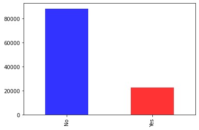

```python
#Plotting show up on a bar graph
colors = ['blue','red']
df['NoShow'].value_counts().plot(kind = 'bar', color=colors, alpha= .8 );
```

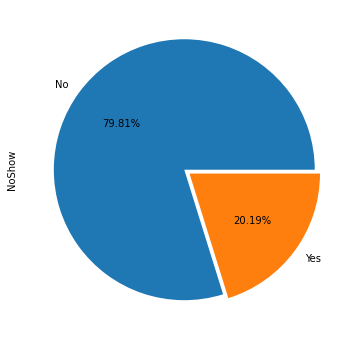

```python
#Plotting Show up in a piechart and checking percentage difference
df['NoShow'].value_counts().plot(kind = 'pie',figsize=(6,6), autopct='%.2f%%', startangle=0, explode=(0, .05));
```

22319 patients as revealed from the data missed their appointments. That means just a little over 20% of all appointments resulted in no shows. Meaning, about 80% of the time patients made it for appointments

### Does the gender of the patient has a relation with the absence?

```python
#Creating functions for patient that showed and those who didn't
Absent = df[df['NoShow'] == 'Yes']
Showed = df[df['NoShow'] == 'No']
```

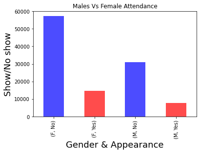

```python
#Bar graph representation of the those who showed and didn't for each gender
df.groupby ('Gender')['NoShow'].value_counts().plot(kind = 'bar', title= 'Males Vs Female Attendance' ,color=colors, alpha=.7 )
plt.xlabel('Gender & Appearance', fontsize=18)
plt.ylabel('Show/No show', fontsize=18);
```

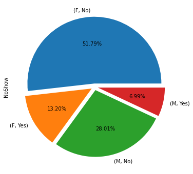

```python
#Pie chart displaying total percentage patient who made it or missed the appointment by gender.
df.groupby('Gender')['NoShow'].value_counts().plot(subplots = True, kind = 'pie',figsize=(6,6), autopct='%.2f%%', startangle=0, explode=(.05, .05 , .05, .05));
```

It from above graphs that there are far more females who had appointments than males. To understand more about which gender miss appointment more, they need to to be look at seperately

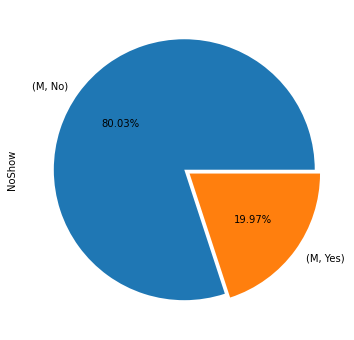

```python
#Pie chart displaying percentage of male patient who made it or missed the appointment.
Males = df[df['Gender'] == 'M']
Males.groupby('Gender')['NoShow'].value_counts().plot( kind = 'pie',figsize=(6,6), autopct='%.2f%%', startangle=0, explode=(0, .05) )
```

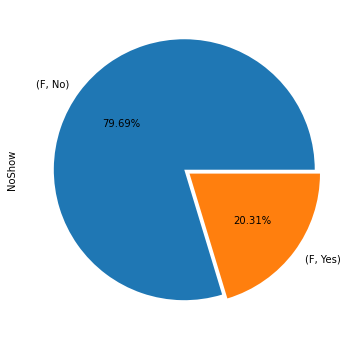

```python
#Pie chart displaying percentage of female patient who made it or missed the appointment
Females = df[df['Gender'] == 'F']
Females.groupby('Gender')['NoShow'].value_counts().plot( kind = 'pie',figsize=(6,6), autopct='%.2f%%', startangle=0, explode=(0, .05) );
```

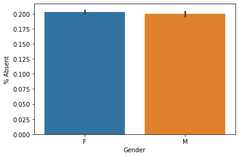

```python
# bar graph of the percentage of noshows for each gender
ax  = sns.barplot(x=df.Gender, y=df.BinNoShow)
ax.set(ylabel='% Absent')
plt.show()
```

From the above graphs one can notice that, though by a little margin, females generally missed thier appointments more than males.

### Does the certian age group attend appoinments than other?

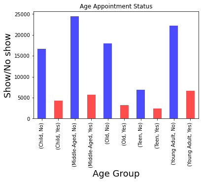

```python
#Bar graph of show andno shows for each age groups
df.groupby ('AgeCatergory')['NoShow'].value_counts().plot(kind = 'bar', title= 'Age Appointment Status' ,color=colors, alpha=.7 )
plt.xlabel('Age Group', fontsize=18)
plt.ylabel('Show/No show', fontsize=18);
```

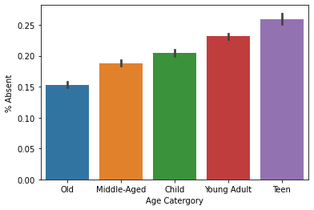

```python
#bar graph of the percentage of noshows for each age group
ax = sns.barplot(x=df.AgeCatergory, y=df.BinNoShow)
ax.set(ylabel='% Absent', xlabel= 'Age Catergory' )
plt.show()
```

The group that miss the most are teens and the group that missed the least are the old.

### Does the day of the week affect the patient attendance?

```python
#Number of patients that showed up or din't show up for each day
df.groupby ('DayOfWeek')['NoShow'].value_counts().to_frame(name='Appointments per Day')
```

| DayOfWeek | NoShow | Appointments per Day |
| --- | --- | --- |
| Friday | No | 14982 |
|  | Yes | 4037 |
| Monday | No | 18024 |
|  | Yes | 4690 |
| Saturday | No | 30 |
|  | Yes | 9 |
| Thursday | No | 13909 |
|  | Yes | 3338 |
| Tuesday | No | 20488 |
|  | Yes | 5152 |
| Wednesday | No | 20774 |
|  | Yes | 5093 |

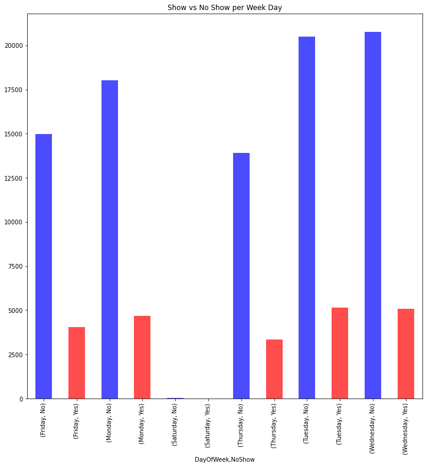

```python
#Bar graph representation of the those who showed and didn't for each week day
df.groupby ('DayOfWeek')['NoShow'].value_counts().plot(kind = 'bar',figsize=(12,12), title= 'Show vs No Show per Week Day' ,color=colors, alpha=.7);
```

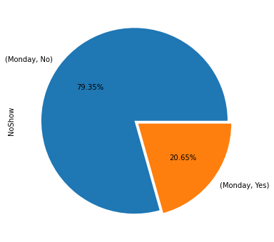

```python
#Pie chart showing the percentage of patients who showed or didn't show up for their appointment on Monday
Monday = df[df['DayOfWeek'] == 'Monday']
Monday.groupby('DayOfWeek')['NoShow'].value_counts().plot(kind = 'pie',figsize=(6,6), autopct='%.2f%%', startangle=0, explode=(0, .05));
```

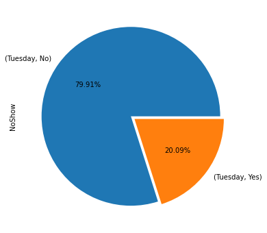

```python
#Pie chart showing the percentage of patients who showed or didn't show up for their appointment on Tuesday
Tuesday = df[df['DayOfWeek'] == 'Tuesday']
Tuesday.groupby('DayOfWeek')['NoShow'].value_counts().plot(kind = 'pie',figsize=(6,6), autopct='%.2f%%', startangle=0, explode=(0, .05));
```

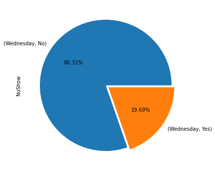

```python
#Pie chart showing the percentage of patients who showed or didn't show up for their appointment on Wednesday
Wednesday = df[df['DayOfWeek'] == 'Wednesday']
Wednesday.groupby('DayOfWeek')['NoShow'].value_counts().plot(kind = 'pie',figsize=(6,6), autopct='%.2f%%', startangle=0, explode=(0, .05));
```

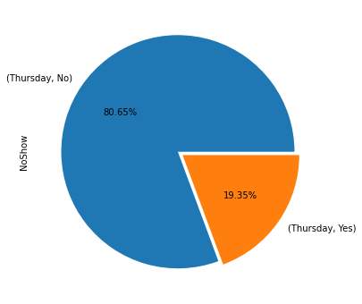

```python
#Pie chart showing the percentage of patients who showed or didn't show up for their appointment on Thursday
Thursday = df[df['DayOfWeek'] == 'Thursday']
Thursday.groupby('DayOfWeek')['NoShow'].value_counts().plot(kind = 'pie',figsize=(6,6), autopct='%.2f%%', startangle=0, explode=(0, .05));
```

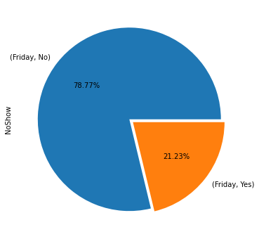

```python
#Pie chart showing the percentage of patients who showed or didn't show up for their appointment on Friday
Friday = df[df['DayOfWeek'] == 'Friday']
Friday.groupby('DayOfWeek')['NoShow'].value_counts().plot(kind = 'pie',figsize=(6,6), autopct='%.2f%%', startangle=0, explode=(0, .05));
```

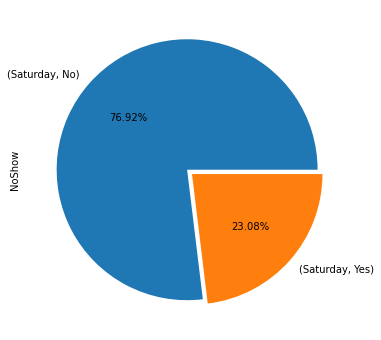

```python
#Pie chart showing the percentage of patients who showed or didn't show up for their appointment on Saturday
Saturday = df[df['DayOfWeek'] == 'Saturday']
Saturday.groupby('DayOfWeek')['NoShow'].value_counts().plot(kind = 'pie',figsize=(6,6), autopct='%.2f%%', startangle=0, explode=(0, .05));
```

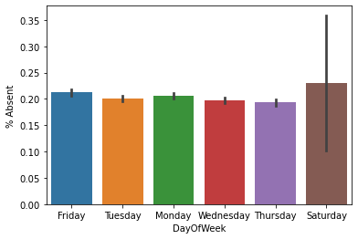

```python
#bar graph of the percentage of noshows for each day of the week
ax = sns.barplot(x=df.DayOfWeek, y=df.BinNoShow)
ax.set(ylabel='% Absent')
plt.show()
```

Though unusual,the day with the most missing saturday. It would be assumped that this is the day many would make it because they may be less busy but that doesn't seem to be the case. The error bar is also highest for Saturdays due to the extremely low incidence of Saturday apointments.

### Did patients miss appointments because of not receiving a message?

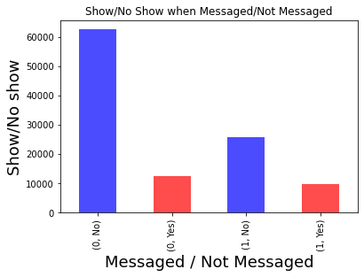

```python
#Bar graph representation of the those who showed and didn't when sent message or not sent message
df.groupby ('SMS_received')['NoShow'].value_counts().plot(kind = 'bar', title= 'Show/No Show when Messaged/Not Messaged' ,color=colors, alpha=.7)
plt.xlabel('Messaged / Not Messaged', fontsize=18)
plt.ylabel('Show/No show', fontsize=18);
```

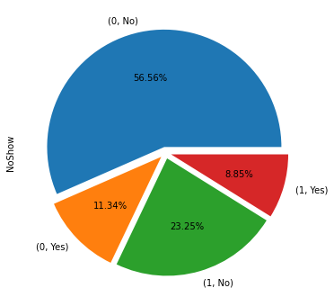

```python
#Pie chart showing the percentage of patients who showed or didn't show up for patients messaged or not messaged
df.groupby('SMS_received')['NoShow'].value_counts().plot(kind = 'pie',figsize=(6,6), autopct='%.2f%%', startangle=0, explode=(.05, .05 , .05, .05));
```

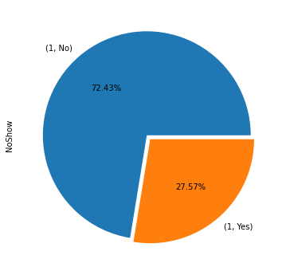

```python
#Pie chart showing the percentage of patients messaged who showed up or didn't show up for their appointment
Messeaged = df[df['SMS_received'] == 1]
Messeaged.groupby('SMS_received')['NoShow'].value_counts().plot(kind = 'pie',figsize=(6,6), autopct='%.2f%%', startangle=0, explode=(0, .05));
```

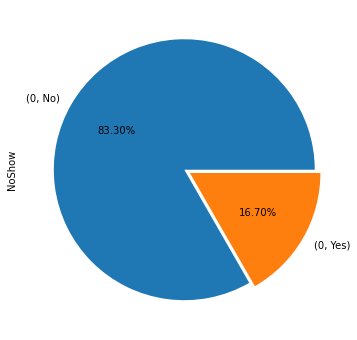

```python
#Pie chart showing the percentage of patients not messaged who showed up or didn't show up for their appointment
Not_messeaged = df[df['SMS_received'] == 0]
Not_messeaged.groupby('SMS_received')['NoShow'].value_counts().plot(kind = 'pie',figsize=(6,6), autopct='%.2f%%', startangle=0, explode=(0, .05));
```

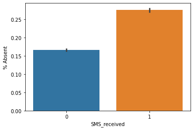

```python
#bar graph of the percentage of noshows for each sms condition
ax = sns.barplot(x=df.SMS_received, y=df.BinNoShow)
ax.set(ylabel='% Absent')
plt.show()
```

Suprisely, patient's who received a message seem to have missed more than patients who didn't receive a message. That's means not receiving a message may not have been the cause for patients missing their appointments.

### Does the scholarship affect the patient's attendance?

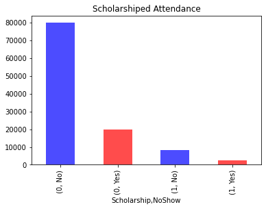

```python
#Bar graph representation of the those who showed up and didn't show up with scholarship or no scholarship
df.groupby('Scholarship')['NoShow'].value_counts().plot(kind = 'bar', title= 'Scholarshiped Attendance' ,color=colors, alpha=.7 );
```

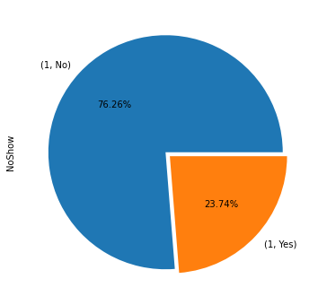

```python
#Pie chart showing the percentage of patients with scholarship who showed up or didn't show up for their appointment
Scholarship = df[df['Scholarship'] == 1]
Scholarship.groupby('Scholarship')['NoShow'].value_counts().plot(kind = 'pie',figsize=(6,6), autopct='%.2f%%', startangle=0, explode=(0, .05));
```

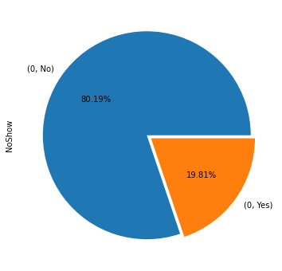

```python
#Pie chart showing the percentage of patients without scholarship who showed up or didn't show up for their appointment
No_scholarship = df[df['Scholarship'] == 0]
No_scholarship.groupby('Scholarship')['NoShow'].value_counts().plot(kind = 'pie',figsize=(6,6), autopct='%.2f%%', startangle=0, explode=(0, .05));
```

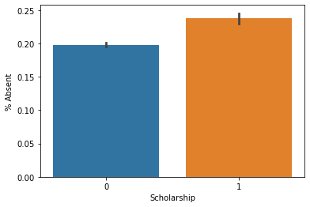

```python
#bar graph of the percentage of noshows for patients with or without scholarship
ax = sns.barplot(x=df.Scholarship, y=df.BinNoShow)
ax.set(ylabel='% Absent')
plt.show()
```

Generally, it seems patients with scholarships miss appointments more patients without scholarships.

## Conclusions

From the dataset analyzed, it is observed that 79.81% (almost 80%) of the patients made it for their appointments while 20.19% of patients missed their appointments. Gender-wise, it can be seen that the percentage of females that missed appointments are more than the percentage of males when they where look at seperately.It's important to note that the population of male patients where less than female patients and for that fact figures of the percentage may have changed if males where as many as females. Also, it is seen that there is a difference between the percentage of no shows within different age groups. The old seem to miss the least while teens miss the most.Though may not be the cause, it is possible the old miss appointment least because people turn to be more conscious of their age when they get older. In addition, certain days of the week was seen to have higher percentages of no shows. Saturday for instance had the least number of appointments but the most percentage of no shows. However, the relationship between SMS received and No Shows was contrary to what was expected as patients who received SMS had more percentage of no shows. Lastly, it is observed that patients with scholarship seem to miss their appointments more than those without scholarships.

### Limitation

One limitation of this analysis was the lack of some background information for the patients. In the analysis of the data, it was found that about 32% of the appointments had SMS messages received. It is possible that those patients were more likely to be encouraged to enroll in SMS notifications after they had already missed an appointment. That would mean that those who were receiving SMS where already having problems making it for appointments. Also,though there is some data on the condition of some patients, there is not data on the kind of health reason for each the appointment since some health reasons are more life treating than others.

### References

Below is a list of websites that I referred to aid in my project.

- https://stackoverflow.com/questions/41256648/select-multiple-ranges-of-columns-in-pandas-dataframe
- https://pandas.pydata.org/docs/reference/frame.html
- https://pandas.pydata.org/pandas-docs/stable/user_guide/visualization.html
- https://pandas.pydata.org/pandas-docs/stable/reference/api/pandas.DataFrame.append.html
- https://stackoverflow.com/questions/41514173/change-multiple-columns-in-pandas-dataframe-to-datetime
- https://stackoverflow.com/questions/66969339/creating-new-column-with-ranges-based-on-existing-column
- https://www.geeksforgeeks.org/python-pandas-series-to_frame/#:~:text=to_frame()%20function%20is%20used,series%20object%20to%20a%20dataframe.&text=Parameter%20%3A,(if%20it%20has%20one).
- https://stackoverflow.com/questions/57967761/how-to-sum-up-yes-and-no-into-a-total-quantity-using-matplotlib-pandas-python
- https://pandas.pydata.org/docs/reference/api/pandas.DataFrame.plot.html
- https://stackoverflow.com/questions/30222533/create-a-day-of-week-column-in-a-pandas-dataframe-using-python
- https://stackoverflow.com/questions/60339049/weekday-name-from-a-pandas-dataframe-date-object
- https://stackoverflow.com/questions/35692781/python-plotting-percentage-in-seaborn-bar-plot
- https://www.geeksforgeeks.org/seaborn-barplot-method-in-python/
- https://www.kaggle.com/datasets/joniarroba/noshowappointments
- https://www.shanelynn.ie/bar-plots-in-python-using-pandas-dataframes/